# R Aula 03

Estudar centralidade e a variabilidade

# Probabilidade

Probabilidade (P) -> valor real entre 0 e 1, 0<= p <= 1

## Distribuição Binomial

Funcoes:

- dbinom(), distribuição binomial
- pbinom(), distribuição cumulativa

dbniom()

- x - numero de sucessos aguardados
- size - numero de eventos
- probabilidade

Buscando 3 sucessos em 5 eventos com espaço igual a 2

```r
dbinom(3, 5, 0.5)
```

```
## [1] 0.3125
```

Sinal de transito de 4 tempos

nenhum sinal aberto -> 4 sinais

```r
dbinom(0, 4, 0.25)
```

```
## [1] 0.3164063
```

encontrar 1 sinal aberto

```r
dbinom(1, 4, 0.25)
```

```
## [1] 0.421875
```

```r
dbinom(2, 4, 0.25)
```

```
## [1] 0.2109375
```

```r
dbinom(3, 4, 0.25)
```

```
## [1] 0.046875
```

```r
dbinom(4, 4, 0.25)
```

```
## [1] 0.00390625
```

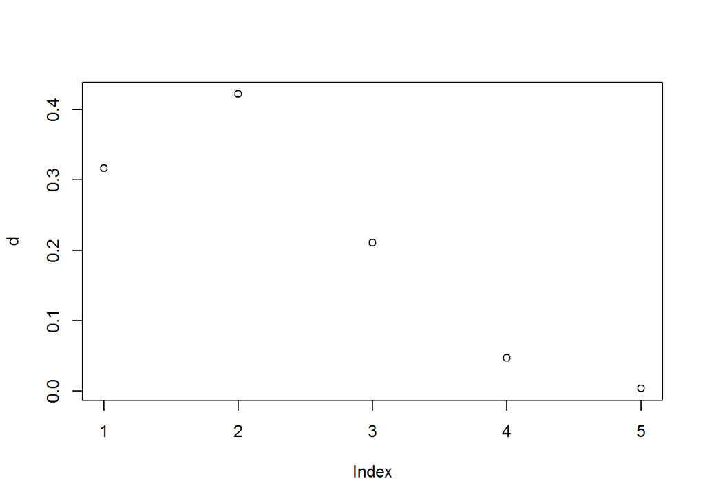

```r
d <- c(dbinom(0, 4, 0.25),dbinom(1, 4, 0.25),dbinom(2, 4, 0.25),dbinom(3, 4, 0.25),dbinom(4, 4, 0.25))

plot(d)
```

## Probabilidade cumulativa

Significa todas as possibilidades possíveis

pbniom calcula a probabilidade cumulativa

```r
pbinom(0, 4, 0.25)
```

```
## [1] 0.3164063
```

```r
pbinom(3, 4, 0.25)
```

```
## [1] 0.9960938
```

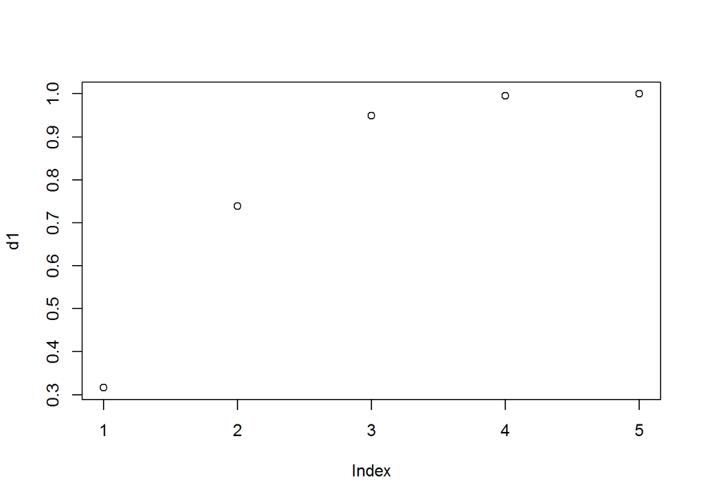

```r
d1 <- c(pbinom(0, 4, 0.25),pbinom(1, 4, 0.25),pbinom(2, 4, 0.25),pbinom(3, 4, 0.25),pbinom(4, 4, 0.25))

plot(d1)
```

Prova de 12 questões quero saber a possibilidade de ter 7 acertos em 4 alternativas

```r
dbinom(7, 12, 0.25)
```

```
## [1] 0.01147127
```

```r
dbinom(12, 12, 0.25)
```

```
## [1] 5.960464e-08
```

# Análise de distribuição normal

Cálculo da probabilidade

Numa distribuição normal eles são distribuidos igualmente pela média, 50% para cada lado

Dois dados são conhecidos:

- Media
- Desvio padrão

O gráfico de normalidade possuem:

- Todos os dados vão estar a 50% da média
- vão estar a uma distância de até 2 desvios padrões

Se isso não ocorrer é pq os dados não estão normalmente distribuídos

## Exemplos

Qual a probabilidade de encontrar um objeto com o peso menos quer 6 kg

- 6kg objeto
- media = 8
- desvio padrão = 2

Média e desvio padrão são dados conhecidos

```r
pnorm(6, 8, 2)
```

```
## [1] 0.1586553
```

```r
pnorm(8, 8, 2)
```

```
## [1] 0.5
```

Invertendo para achar o outro lado da cauda

```r
pnorm(6, 8, 2, lower.tail = F)
```

```
## [1] 0.8413447
```

Encontrando a probabilidade de ser maior que 10 kg

```r
pnorm(10, 8, 2, lower.tail = F)
```

```
## [1] 0.1586553
```

# Probabilidade acumulativa

Qual a probabilidade de ter menos de 6 kg ou mais de 10 kg

```r
pnorm(6, 8, 2) + pnorm(10, 8, 2, lower.tail = F)
```

```
## [1] 0.3173105
```

Qual a probabilidade de encontrar um objeto com menos de 10 kg e mais de 8 kg

```r
pnorm(10, 8, 2) - pnorm(8, 8, 2)
```

```
## [1] 0.3413447
```

## Diagrama de normalidade usando a função rnorm()

Criar um conjunto de dados com numeros normalmente distribuidos

```r
x <- rnorm(100, sd = 2)
x
```

```
##   [1] -2.328186223  1.717011102  3.790805961 -0.615283826 -1.008708949
##   [6]  2.620766637 -1.040488398 -1.454736160 -0.029992727 -1.484857938
##  [11]  1.882292995 -0.867062504  3.078621244  0.278963850 -4.494851924
##  [16] -1.611601090 -3.397307518 -1.398256343 -2.548180784  1.685477045
##  [21]  1.361556859  0.269605004 -0.921230128  1.896842892 -1.095047704
##  [26]  0.550396780  1.492127288  3.151227377  1.180708999 -2.671371197
##  [31]  0.021156128 -1.758725017  1.859263192 -1.013049756  1.509549040
##  [36] -0.451702187  4.087379667 -4.005570713  1.756009845 -3.316382027
##  [41]  1.378682356  2.016342213  1.211623382  3.178799472  2.414330051
##  [46]  0.876910051 -0.282391815 -1.429101463  0.298118846 -0.586770531
##  [51]  0.109441662  3.873527173 -1.319738152 -1.591694721 -1.402155685
##  [56]  0.983367216  0.480803561  3.247095970  0.198606603 -0.564199004
##  [61] -2.108654038 -0.834054486  0.913672227 -0.465599307  1.437055864
##  [66] -1.040392386 -1.160123638 -0.605632976 -3.232932875 -0.872127215
##  [71]  3.100872401  0.068101638 -3.205311089  1.642744464  0.119082959
##  [76]  2.160362560 -0.878044411  2.164770585 -1.274392095 -3.749528325
##  [81] -1.750644725 -1.808814283  0.001487809  1.713733916  2.263394785
##  [86]  1.231200192  1.933782061 -4.664733525  3.080288156  2.557007099
##  [91] -1.642390365  0.010167808 -2.056169319  0.371670106 -1.460410293
##  [96] -0.909250674  1.217317083  0.648294328 -1.907378509 -0.093493367
```

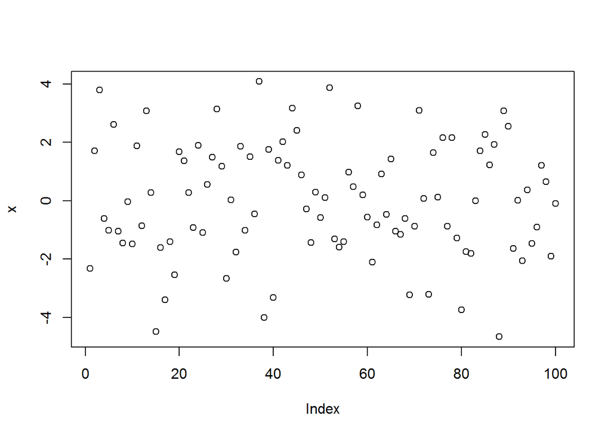

```r
plot(x)
```

### Gerar o gráfico de normalidade

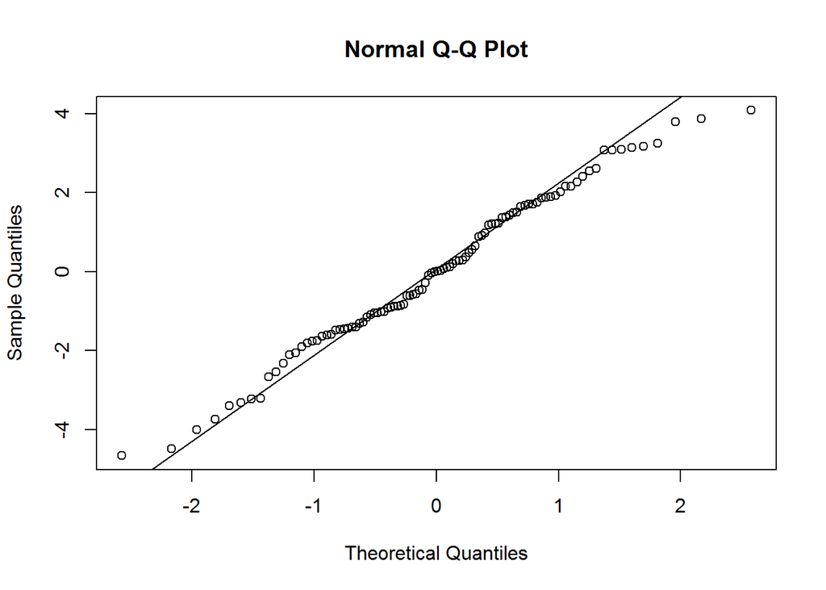

```r
qqnorm(x)
qqline(x)
```

### Shapiro test

```r
shapiro.test(x)
```

```
##
##  Shapiro-Wilk normality test
##
## data:  x
## W = 0.9863, p-value = 0.3922
```

# Regressão linear simples

Estuda relação entre uma variável chamada de dependente e outras variáveis chamadas independentes.

## Modelo de regressão linear simples

Relação entre uma varável dependente e uma variável independente

Exemplos:

- Altura dos pais e dos filhos
- Renda semanal e despesas de consumo
- Idade e custo ao plano de saúde

## Regressão linear

Correlação:

- Mostra a força e a direção da relação entre variáveis
- pode ser um valor entre -1 e 1
- A correlação de A~B é a mesma que B~A
- Ela tem força e direção
- Se for 1 ou -1 é perfeita
- Se for 0 ela não existe
- Ela pode ser forte até 0.5 ou -0.5
- Ela pode ser forte acima de 0.7 ou -0.7
- Pode ser fraca

## Coeficiente de determinação

- Mostra o quanto o modelo consegue explicar os valores
- Quanto maior, mais explicativo ele é
- O restante da variabilidade está em variáveis não incluídas no modelo
- Varia entre 0 e 1
- Calcua com o quadrado coeficiente da correlação

## Linha de melhor ajuste

Ponto de encontro da linha do Eixo Y(Intersecção): X = 0 Inclinação: a cada unidade que amenta a variável independente(x), a variável dependente(y) sobe o valor da inclinação. Planilhas e Feramentas calculam os valores da intersecção e inclinação.

## Previsão de novo valor

Formula: previsão = Intersecção + (Inclinação * valor a prever)

## Residuais

A linha de regressão é um ajustecriado com os dados forncidos na criação do modelo, ele é utilizado para criar a linha de regeressão

## Outliers

São valores fora do padrão de dados. Podem influenciar o modelo de forma negativa. A correlçaõ pode diminuir por causa do outliers

## Extrapolação

Efetuar uma previsão para fora ou depois da regressão. A linearidade da linha de regressão pode se comportar de forma diferente, ou seja, a previsão da extrapolação deve ser avaliada.

## Correlação não é causa

A correlação não é a causa da relação, ou seja, a causa pode ser uma variável que não está sendo estudado no modelo

## Codigos

Prever a distância de parada

```r
data("cars")

cars
```

| speed | dist |
| --- | --- |
| 4 | 2 |
| 4 | 10 |
| 7 | 4 |
| 7 | 22 |
| 8 | 16 |
| 9 | 10 |
| 10 | 18 |
| 10 | 26 |
| 10 | 34 |
| 11 | 17 |

[output cut: 40 more lines]

```r
dim(cars)
```

```
## [1] 50  2
```

```r
summary(cars)
```

```
##      speed           dist
##  Min.   : 4.0   Min.   :  2.00
##  1st Qu.:12.0   1st Qu.: 26.00
##  Median :15.0   Median : 36.00
##  Mean   :15.4   Mean   : 42.98
##  3rd Qu.:19.0   3rd Qu.: 56.00
##  Max.   :25.0   Max.   :120.00
```

Verificar a correlação

```r
cor(cars)
```

```
##           speed      dist
## speed 1.0000000 0.8068949
## dist  0.8068949 1.0000000
```

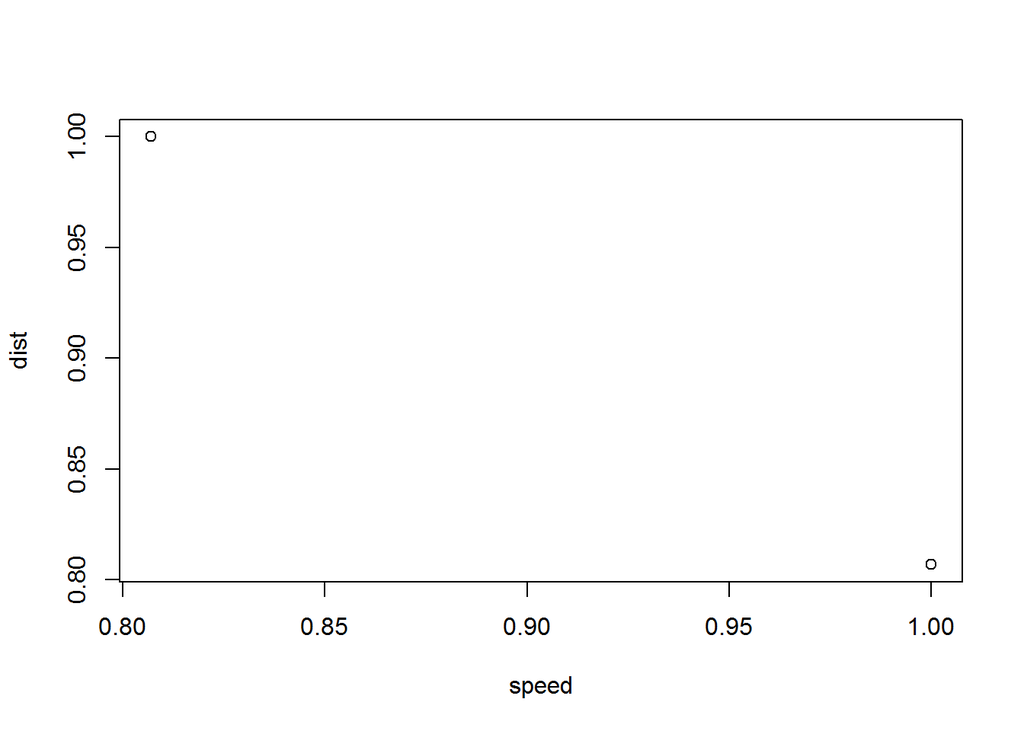

```r
plot(cor(cars))
```

Função do modelo linear

Modelo: velocidade sendo explicada pela distância

```r
modelo <- lm(speed ~ dist, cars)
modelo
```

```
##
## Call:
## lm(formula = speed ~ dist, data = cars)
##
## Coefficients:
## (Intercept)         dist
##      8.2839       0.1656
```

A intersecção é o Intercept(tudo que eu tenho) e a incliniação é o dist(o quanto eu tenho que crescer)

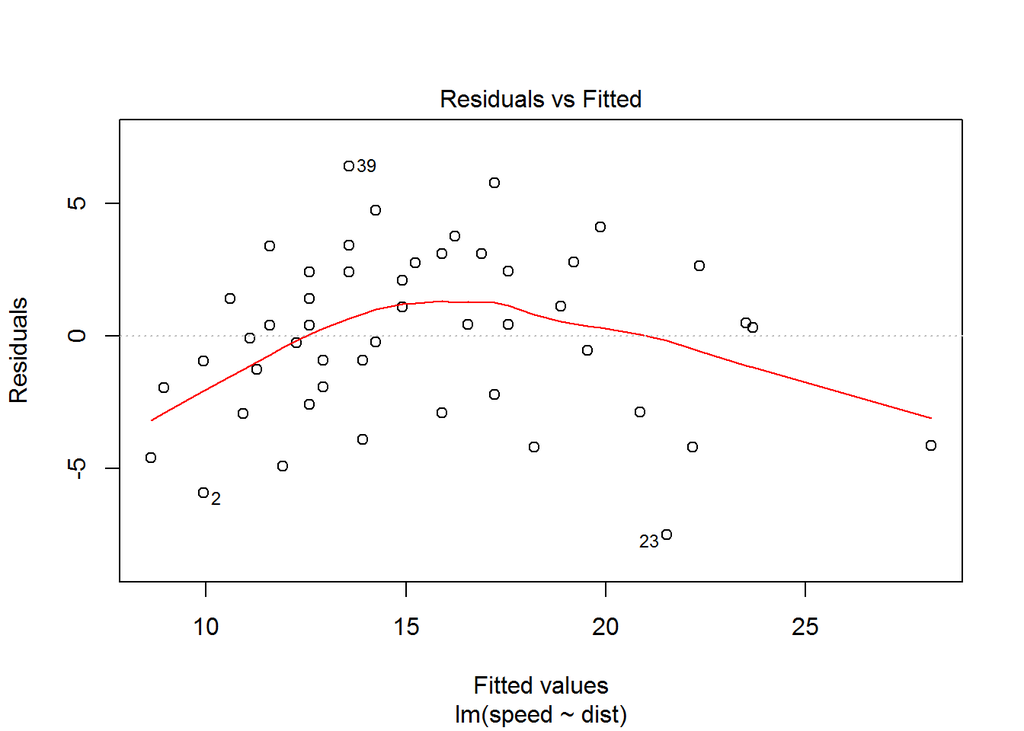

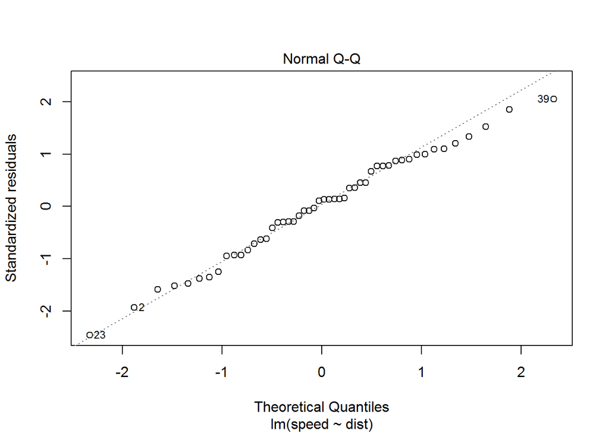

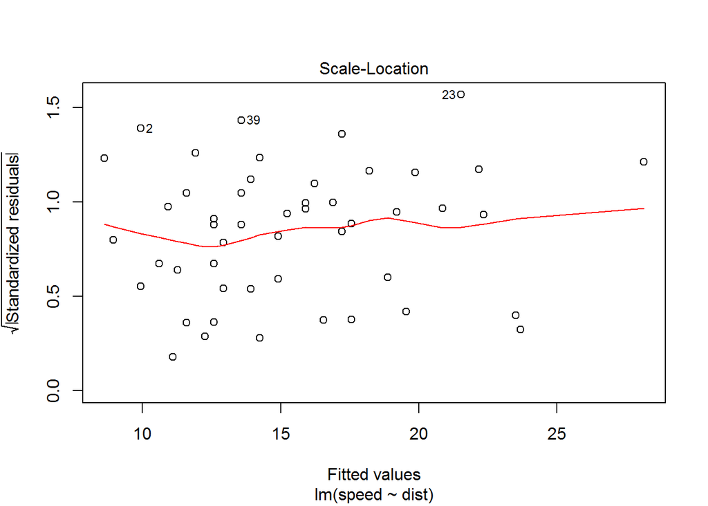

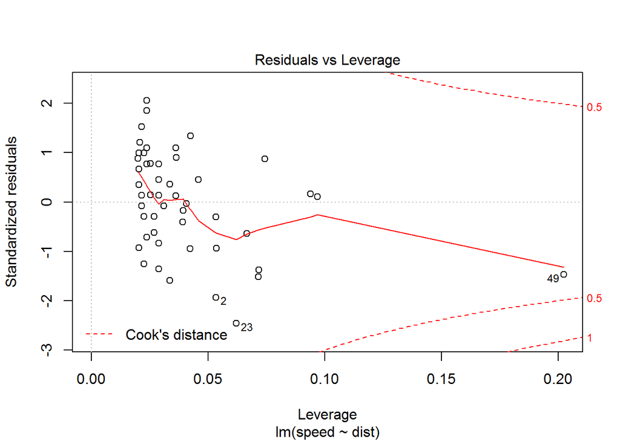

```r
plot(modelo)
```

Plot de dispersao

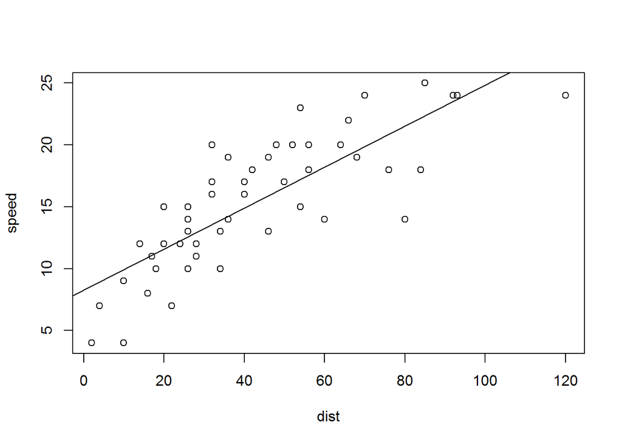

```r
plot(speed ~ dist, data = cars)
abline(modelo) #linha de melhor ajuste
```

A uma distência de 22 a velocidade e aproximadamente 12

```r
funcao <- function(interseccao, inclinacao, valor){
  return(interseccao + (inclinacao * valor))
}

funcao(modelo$coefficients[1], modelo$coefficients[2], 22 )
```

```
## (Intercept)
##    11.92639
```

Usando o R para efetuar previsão

```r
predict(modelo, data.frame(dist = 22))
```

```
##        1
## 11.92639
```

```r
summary(modelo)
```

```
##
## Call:
## lm(formula = speed ~ dist, data = cars)
##
## Residuals:
##     Min      1Q  Median      3Q     Max
## -7.5293 -2.1550  0.3615  2.4377  6.4179
##
## Coefficients:
##             Estimate Std. Error t value Pr(>|t|)
## (Intercept)  8.28391    0.87438   9.474 1.44e-12 ***
## dist         0.16557    0.01749   9.464 1.49e-12 ***
## ---
## Signif. codes:  0 '***' 0.001 '**' 0.01 '*' 0.05 '.' 0.1 ' ' 1
##
## Residual standard error: 3.156 on 48 degrees of freedom
## Multiple R-squared:  0.6511, Adjusted R-squared:  0.6438
## F-statistic: 89.57 on 1 and 48 DF,  p-value: 1.49e-12
```

```r
modelo$coefficients
```

```
## (Intercept)        dist
##   8.2839056   0.1655676
```

```r
modelo$residuals
```

```
##           1           2           3           4           5           6
## -4.61504079 -5.93958139 -1.94617594 -4.92639228 -2.93298684 -0.93958139
##           7           8           9          10          11          12
## -1.26412199 -2.58866258 -3.91320318 -0.09855441 -1.91979773  1.39814831
##          13          14          15          16          17          18
##  0.40474287 -0.25752743 -0.91979773  0.41133742 -0.91320318 -0.91320318
##          19          20          21          22          23          24
## -2.90001408  1.41133742 -0.24433833 -4.21796012 -7.52931161  3.40474287
##          25          26          27          28          29          30
##  2.41133742 -2.22455467  2.41793197  1.09339137  3.41793197  2.09339137
##          31          32          33          34          35          36
##  0.43771563  2.76225622  0.44431018 -2.86704131 -4.19158191  4.75566167
##          37          38          39          40          41          42
##  3.09998592 -0.54250072  6.41793197  3.76885078  3.10658048  2.44431018
##          43          44          45          46          47          48
##  1.11976958  2.78863443  5.77544533  4.12636413  0.48387749  0.31830992
##          49          50
## -4.15201460  2.64285051
```

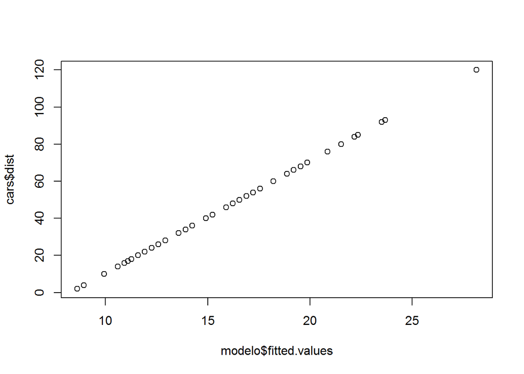

```r
plot(modelo$fitted.values, cars$dist)
```

Os fitted values são usados para criar a linha de melhor ajuste do abline()

# Modelo de regressão linear multipla

```r
data("mtcars")
mtcars
```

|  | mpg | cyl | disp | hp | drat | wt | qsec | vs | am | gear | carb |
| --- | --- | --- | --- | --- | --- | --- | --- | --- | --- | --- | --- |
| Mazda RX4 | 21.0 | 6 | 160.0 | 110 | 3.90 | 2.620 | 16.46 | 0 | 1 | 4 | 4 |
| Mazda RX4 Wag | 21.0 | 6 | 160.0 | 110 | 3.90 | 2.875 | 17.02 | 0 | 1 | 4 | 4 |
| Datsun 710 | 22.8 | 4 | 108.0 | 93 | 3.85 | 2.320 | 18.61 | 1 | 1 | 4 | 1 |
| Hornet 4 Drive | 21.4 | 6 | 258.0 | 110 | 3.08 | 3.215 | 19.44 | 1 | 0 | 3 | 1 |
| Hornet Sportabout | 18.7 | 8 | 360.0 | 175 | 3.15 | 3.440 | 17.02 | 0 | 0 | 3 | 2 |
| Valiant | 18.1 | 6 | 225.0 | 105 | 2.76 | 3.460 | 20.22 | 1 | 0 | 3 | 1 |
| Duster 360 | 14.3 | 8 | 360.0 | 245 | 3.21 | 3.570 | 15.84 | 0 | 0 | 3 | 4 |
| Merc 240D | 24.4 | 4 | 146.7 | 62 | 3.69 | 3.190 | 20.00 | 1 | 0 | 4 | 2 |
| Merc 230 | 22.8 | 4 | 140.8 | 95 | 3.92 | 3.150 | 22.90 | 1 | 0 | 4 | 2 |
| Merc 280 | 19.2 | 6 | 167.6 | 123 | 3.92 | 3.440 | 18.30 | 1 | 0 | 4 | 4 |

[output cut: 22 more lines]

```r
#fix(mtcars)
head(mtcars)
```

|  | mpg | cyl | disp | hp | drat | wt | qsec | vs | am | gear | carb |
| --- | --- | --- | --- | --- | --- | --- | --- | --- | --- | --- | --- |
| Mazda RX4 | 21.0 | 6 | 160 | 110 | 3.90 | 2.620 | 16.46 | 0 | 1 | 4 | 4 |
| Mazda RX4 Wag | 21.0 | 6 | 160 | 110 | 3.90 | 2.875 | 17.02 | 0 | 1 | 4 | 4 |
| Datsun 710 | 22.8 | 4 | 108 | 93 | 3.85 | 2.320 | 18.61 | 1 | 1 | 4 | 1 |
| Hornet 4 Drive | 21.4 | 6 | 258 | 110 | 3.08 | 3.215 | 19.44 | 1 | 0 | 3 | 1 |
| Hornet Sportabout | 18.7 | 8 | 360 | 175 | 3.15 | 3.440 | 17.02 | 0 | 0 | 3 | 2 |
| Valiant | 18.1 | 6 | 225 | 105 | 2.76 | 3.460 | 20.22 | 1 | 0 | 3 | 1 |

```r
dim(mtcars)
```

```
## [1] 32 11
```

```r
cor(mtcars[1:4])
```

```
##             mpg        cyl       disp         hp
## mpg   1.0000000 -0.8521620 -0.8475514 -0.7761684
## cyl  -0.8521620  1.0000000  0.9020329  0.8324475
## disp -0.8475514  0.9020329  1.0000000  0.7909486
## hp   -0.7761684  0.8324475  0.7909486  1.0000000
```

Regressão simples

```r
modelo <- lm(mpg ~ disp, data = mtcars)
modelo
```

```
##
## Call:
## lm(formula = mpg ~ disp, data = mtcars)
##
## Coefficients:
## (Intercept)         disp
##    29.59985     -0.04122
```

Coeficiente de determinação, diz o quanto o modelo está explicado

```r
summary(modelo)$r.squared
```

```
## [1] 0.7183433
```

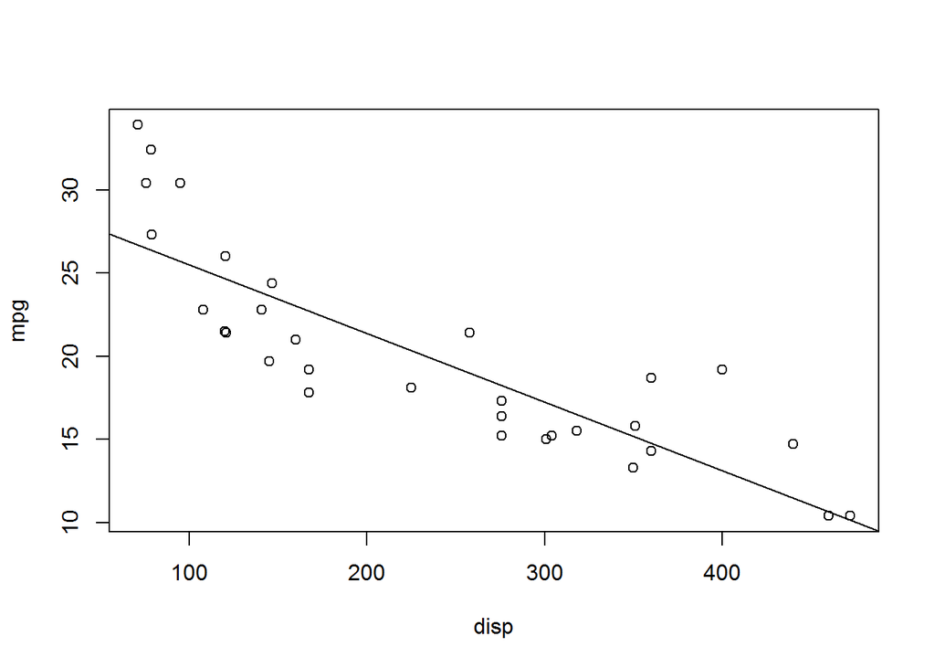

```r
plot(mpg ~disp, data = mtcars)
abline(modelo)
```

Quer prever o mpg para um carro

```r
predict(modelo, data.frame(disp = 200))
```

```
##        1
## 21.35683
```

```r
head(mtcars[1:4])
```

|  | mpg | cyl | disp | hp |
| --- | --- | --- | --- | --- |
| Mazda RX4 | 21.0 | 6 | 160 | 110 |
| Mazda RX4 Wag | 21.0 | 6 | 160 | 110 |
| Datsun 710 | 22.8 | 4 | 108 | 93 |
| Hornet 4 Drive | 21.4 | 6 | 258 | 110 |
| Hornet Sportabout | 18.7 | 8 | 360 | 175 |
| Valiant | 18.1 | 6 | 225 | 105 |

## Modelo de rgressão multípla

```r
modelo <- lm(mpg ~ disp + cyl + hp, data = mtcars)
modelo
```

```
##
## Call:
## lm(formula = mpg ~ disp + cyl + hp, data = mtcars)
##
## Coefficients:
## (Intercept)         disp          cyl           hp
##    34.18492     -0.01884     -1.22742     -0.01468
```

```r
summary(modelo)$r.squared
```

```
## [1] 0.7678877
```

```r
summary(modelo)$adj.r.squared
```

```
## [1] 0.7430186
```

```r
predict(modelo, data.frame(disp = 200, hp = 100, cyl = 4))
```

```
##        1
## 24.03969
```

# Outliers

Iris -> datasets

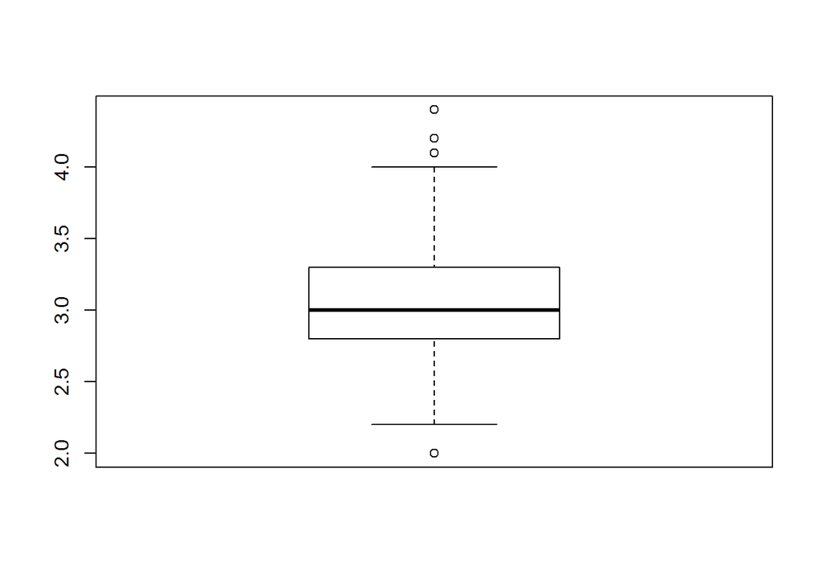

```r
data("iris")
boxplot(iris$Sepal.Width)
```

Não quero mostrar outliers

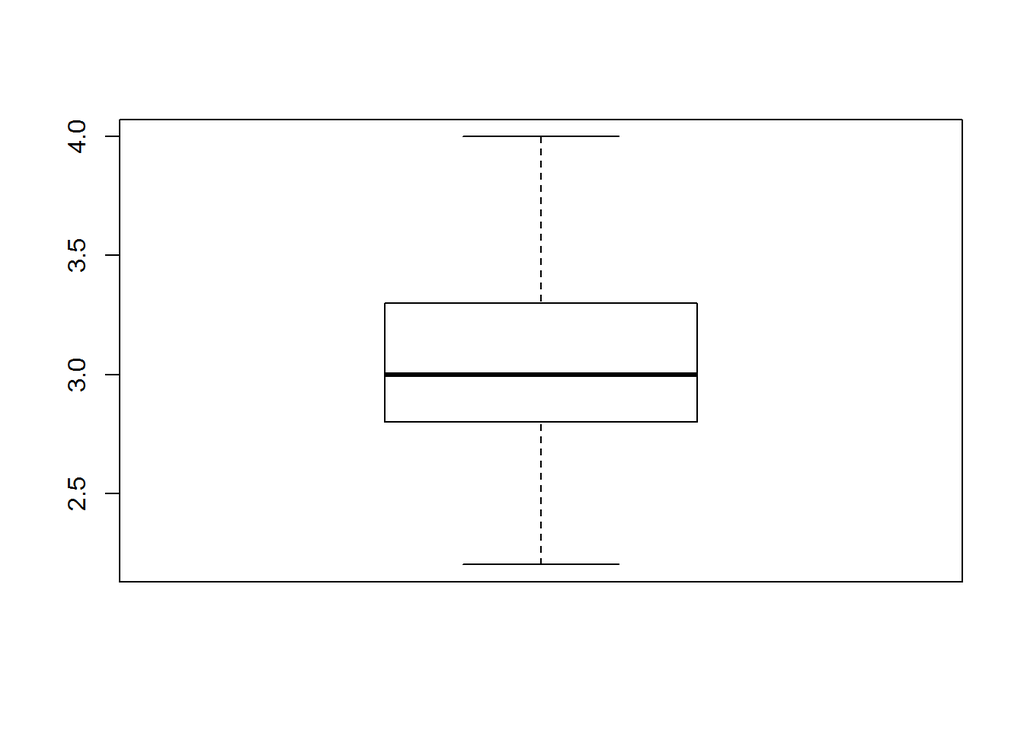

```r
boxplot(iris$Sepal.Width, outline = F)
```

Stats -> exibir os outliers de uma coleção

Somente os outliers

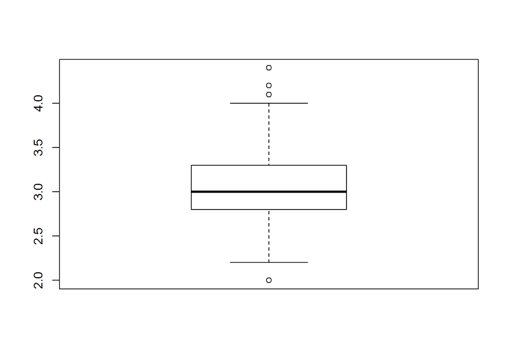

```
## [1] 4.4 4.1 4.2 2.0
```

```r
boxplot(iris$Sepal.Width)$out
```

```r
library('outliers')
```

Amostrar o superiore

```r
outlier(iris$Sepal.Width)
```

```
## [1] 4.4
```

Amostrar o inferior

```r
outlier(iris$Sepal.Width, opposite = T)
```

```
## [1] 2
```